# **3. Baseline Models**

### Question 1

We have trained the Logistic Regression model with default settings and after looking at the predictions we see that there are no predictions for goals. This can be due to a huge difference in the number of goals and no goals.

### Question 3

In the ROC-AUC Curve, we see that the models trained on “Distance” and “Distance and Angle” have the same behavior and are away from the baseline whereas the model trained on “Angle” is closer to baseline which proves that it's not a good feature to predict the goal.

In the Goal Rate curve, we see that models trained on “Distance” and “Distance and Angle” have a decrease in the goal rate as the shot probability model percentile decreases. Though it's not linear we can still see an overall decrease whereas the model trained on “Angle” has a varied goal rate for shot probability model percentile. It's not able to predict the correct goal rate based on the shot probability model percentile.

In the Reliability curve, we see that the model trained on “Distance” and “Distance and Angle” are near to the perfectly calibrated line but still not perfect as it has lots of variations. But for the model trained on ‘Angle’ even though it lies on the perfectly collaborated line it has a single mean predicted probability.

### Comet links and figures

1. [Logistic Regression, trained on distance only](https://www.comet.ml/maskedviper/milestone-2/5b2a0c78f34b4164a0d350594977b35e)
2. [Logistic Regression, trained on angle only](https://www.comet.ml/maskedviper/milestone-2/0d17bff86b0b430eb45128c1d1c38b83)
3. [Logistic Regression, trained on both distance and angle only](https://www.comet.ml/maskedviper/milestone-2/704df345e0f54df28b65407e6d6f5cf1)

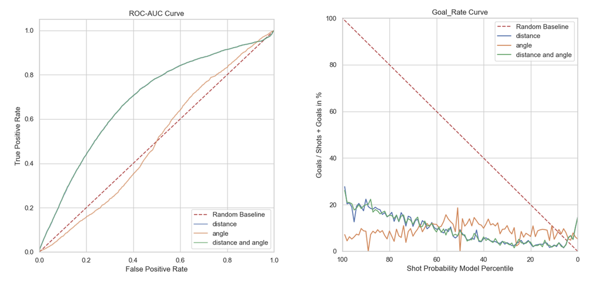

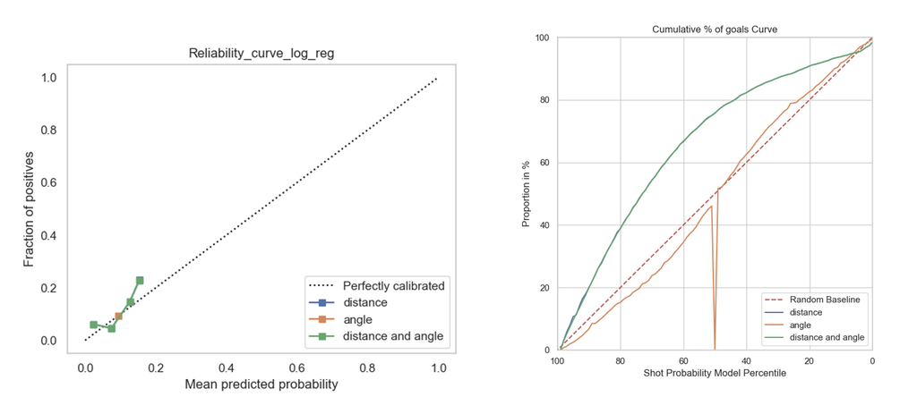